# Student Housing Costs

## Background

Stephanie[^1] is a student that will be starting school at BYU-Idaho next semester. Here is a copy of the email request for information that she sent.

“Hi. My name is Stephanie. I would like to learn about what housing options I have for living at BYU-Idaho next semester. It will be my first semester there, so I would like to find something that is close to campus and around $300 a month in rent. I’m not too picky on roomates, but I would like somewhere that has a lot of people around so I can get to know as many people as possible. Thanks in advance!”

The data from the [BYU-Idaho Housing Website](https://web.byui.edu/tis/search) has data from all the BYUI approved housing.

### Dataset of Female Housing

|  | Apartment | Gender | Address | Phone | Cost | CostHigh | Residents | ParkingStalls | Website | Miles2Campus | WalkMinutes |
| --- | --- | --- | --- | --- | --- | --- | --- | --- | --- | --- | --- |
| 1 | ABBY LANE MANOR | F | 437 S 4TH W | (208) 359-3687 | 1035 | 1060 | 42 | 38 | www.abbylaneapartments.com | 0.745647284 | 16 |
| 4 | ABRI APARTMENTS - WOMEN | F | 220 E 1ST S | (208) 417-7223 | 1445 | 1495 | 150 | 216 | www.liveabri.com | 0.310686368 | 8 |
| 5 | ALBION APARTMENT | F | 231 W 2ND S | (801) 856-0732 | 1062.5 | 1150 | 5 | 4 |  | 0.186411821 | 4 |
| 6 | ALEXANDER APARTMENT | F | 276 W 3RD S | 208-995-8543 | 972.5 | 1115 | 22 | 18 | www.alexanderapartments.wordpress.com | 0.434960916 | 8 |
| 7 | ALLDREDGE HOUSE | F | 243 S 1ST E | 208-206-4697 | 1045 | 1095 | 8 | 8 |  | 0.186411821 | 5 |
| 10 | ALLEN'S SUNRISE VILLAGE - WOMEN | F | 48 W 2ND S | 208-356-3995 | 1000 | 1075 | 144 | 133 | www.sunrisevillageapts.com | 0.062137274 | 1 |
| 14 | AMERICAN AVENUE - WOMEN | F | 151 S 1ST E | (208) 356-5097 | 1050 | 1075 | 165 | 0 | myamericanavenue.com | 0.372823642 | 7 |
| 19 | ASPEN VILLAGE - WOMEN | F | 545 S 2ND E | (208) 356-7701 | 900 | 1000 | 210 | 84 | www.aspenvillageapartments.com | 0.372823642 | 6 |
| 20 | AT THE GROVE | F | 349 HARVARD AVE | 801-319-4334 |  |  | 6 | 5 | https://www.facebook.com/atthegroveapts/ | 0.186411821 | 3 |
| 21 | AUTUMN WINDS | F | 160 W 5TH S | (208) 356-0821 | 1345 | 1345 | 96 | 96 | www.rexburghousing.com | 0.434960916 | 9 |

[output cut: 47 more lines]

## Analysis

### Summary statistics of Female Housing Costs

```
##  min  Q1 median   Q3  max     mean       sd  n missing
##  870 995   1125 1277 1585 1146.685 183.1662 55       2
```

### Graphical Description of Female Housing Costs

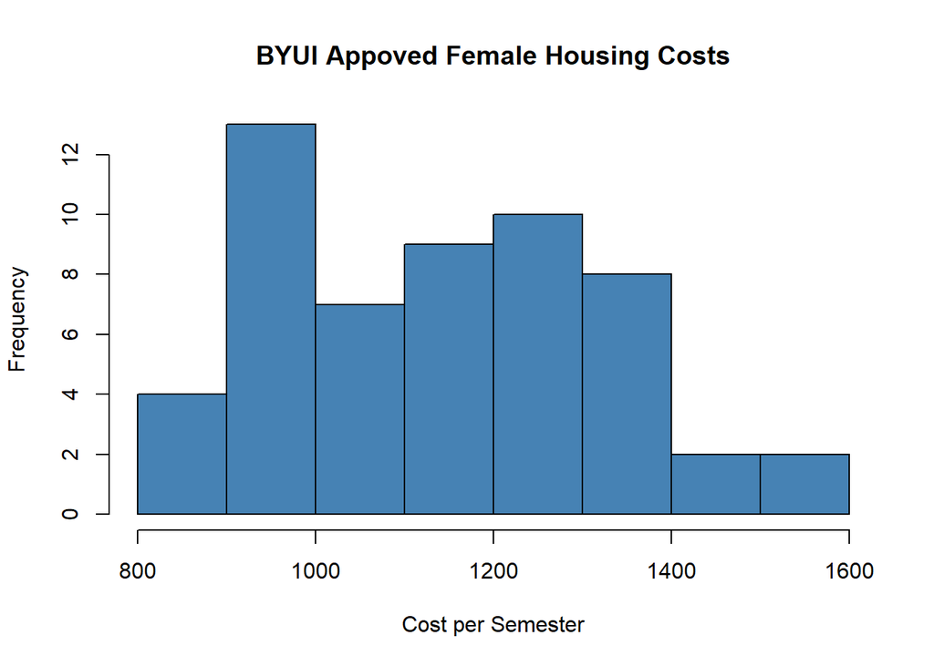

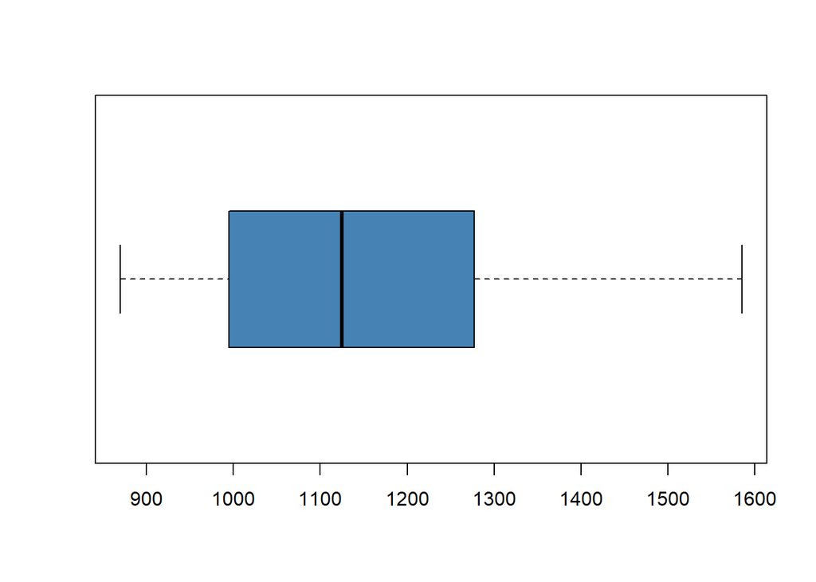

## Interpretation

Stephanie says she would like to budget $300 per month; in a 14 week semester that would mean she is looking for about $970 per semester. If she is firm on that number she will be limited to these apartments:

### Stephanie’s options by price

|  | Apartment | Cost | CostHigh | Residents | ParkingStalls | Miles2Campus |
| --- | --- | --- | --- | --- | --- | --- |
| 19 | ASPEN VILLAGE - WOMEN | 900 | 1000 | 210 | 84 | 0.372823642 |
| 23 | BAYSIDE MANOR | 960 | 960 | 8 | 8 | 0.124274547 |
| 33 | BROOKLYN APARTMENTS | 870 | 895 | 144 | 0 | 0.372823642 |
| 36 | BUENA VISTA | 925 | 925 | 21 | 7 | 0.310686368 |
| 53 | COTTONWOOD-WOMEN | 950 | 950 | 84 | 100 | 0.248549095 |
| 57 | CRESTWOOD COTTAGE | 940 | 940 | 10 | 10 | 0.248549095 |
| 60 | DAVENPORT APARTMENTS | 895 | 895 | 71 | 30 | 0.186411821 |
| 74 | HILL'S COLLEGE AVE APTS | 880 | 880 | 11 | 3 | 0.310686368 |
| 106 | SHADETREE APARTMENT | 915 | 950 | 6 | 0 | 0.186411821 |
| 113 | SUNSET HALL | 967 | 967 | 14 | 0 | 0.248549095 |

### More considerations

Stephanie’s other requirement is that she would like to be around a lot of people. This could mean a lot of people in the housing complex or a housing complex that is near campus. Of the apartment complexes that meet the price requirements, distance does not vary that much; the size of the housing complexes vary a great deal.

### Final Suggestion

Based off of Stephanie’s criteria, my suggestion is that Stephanie consider these three complexes:

|  | Apartment | Cost | CostHigh | Residents | ParkingStalls | Miles2Campus |
| --- | --- | --- | --- | --- | --- | --- |
| 19 | ASPEN VILLAGE - WOMEN | 900 | 1000 | 210 | 84 | 0.372823642 |
| 33 | BROOKLYN APARTMENTS | 870 | 895 | 144 | 0 | 0.372823642 |
| 53 | COTTONWOOD-WOMEN | 950 | 950 | 84 | 100 | 0.248549095 |

[^1]: Note that Stephanie is a fictional character who is based on real experiences of many faculty and staff here at BYU-Idaho.